# Risk Factor Analysis

## Outcome Variable

**Outcome Variable:** ever_stunted

## Predictor Variables

**Intervention Variable:** tr.x

**Adjustment Set:**

unadjusted

## Stratifying Variables

The analysis was stratified on these variable(s):

- parity
- agecat
- studyid
- country

## Data Summary

| parity | agecat | studyid | country | tr.x | ever_stunted | n_cell | n |
| --- | --- | --- | --- | --- | --- | --- | --- |
| 1 | 0-6 months | ki1000110-WASH-Bangladesh | BANGLADESH | Control | 0 | 11 | 78 |
| 1 | 0-6 months | ki1000110-WASH-Bangladesh | BANGLADESH | Control | 1 | 2 | 78 |
| 1 | 0-6 months | ki1000110-WASH-Bangladesh | BANGLADESH | LNS | 0 | 21 | 78 |
| 1 | 0-6 months | ki1000110-WASH-Bangladesh | BANGLADESH | LNS | 1 | 2 | 78 |
| 1 | 0-6 months | ki1000110-WASH-Bangladesh | BANGLADESH | Other | 0 | 35 | 78 |
| 1 | 0-6 months | ki1000110-WASH-Bangladesh | BANGLADESH | Other | 1 | 7 | 78 |
| 3+ | 0-6 months | ki1000110-WASH-Bangladesh | BANGLADESH | Control | 0 | 16 | 73 |
| 3+ | 0-6 months | ki1000110-WASH-Bangladesh | BANGLADESH | Control | 1 | 1 | 73 |
| 3+ | 0-6 months | ki1000110-WASH-Bangladesh | BANGLADESH | LNS | 0 | 17 | 73 |
| 3+ | 0-6 months | ki1000110-WASH-Bangladesh | BANGLADESH | LNS | 1 | 1 | 73 |
| 3+ | 0-6 months | ki1000110-WASH-Bangladesh | BANGLADESH | Other | 0 | 36 | 73 |
| 3+ | 0-6 months | ki1000110-WASH-Bangladesh | BANGLADESH | Other | 1 | 2 | 73 |
| 2 | 0-6 months | ki1000110-WASH-Bangladesh | BANGLADESH | Control | 0 | 9 | 70 |
| 2 | 0-6 months | ki1000110-WASH-Bangladesh | BANGLADESH | Control | 1 | 3 | 70 |
| 2 | 0-6 months | ki1000110-WASH-Bangladesh | BANGLADESH | LNS | 0 | 21 | 70 |
| 2 | 0-6 months | ki1000110-WASH-Bangladesh | BANGLADESH | LNS | 1 | 2 | 70 |
| 2 | 0-6 months | ki1000110-WASH-Bangladesh | BANGLADESH | Other | 0 | 34 | 70 |
| 2 | 0-6 months | ki1000110-WASH-Bangladesh | BANGLADESH | Other | 1 | 1 | 70 |
| 2 | 0-6 months | ki1000304b-SAS-CompFeed | INDIA | Control | 0 | 58 | 193 |
| 2 | 0-6 months | ki1000304b-SAS-CompFeed | INDIA | Control | 1 | 21 | 193 |
| 2 | 0-6 months | ki1000304b-SAS-CompFeed | INDIA | Other | 0 | 85 | 193 |
| 2 | 0-6 months | ki1000304b-SAS-CompFeed | INDIA | Other | 1 | 29 | 193 |
| 1 | 0-6 months | ki1000304b-SAS-CompFeed | INDIA | Control | 0 | 82 | 231 |
| 1 | 0-6 months | ki1000304b-SAS-CompFeed | INDIA | Control | 1 | 28 | 231 |
| 1 | 0-6 months | ki1000304b-SAS-CompFeed | INDIA | Other | 0 | 83 | 231 |
| 1 | 0-6 months | ki1000304b-SAS-CompFeed | INDIA | Other | 1 | 38 | 231 |
| 3+ | 0-6 months | ki1000304b-SAS-CompFeed | INDIA | Control | 0 | 124 | 368 |
| 3+ | 0-6 months | ki1000304b-SAS-CompFeed | INDIA | Control | 1 | 54 | 368 |
| 3+ | 0-6 months | ki1000304b-SAS-CompFeed | INDIA | Other | 0 | 137 | 368 |
| 3+ | 0-6 months | ki1000304b-SAS-CompFeed | INDIA | Other | 1 | 53 | 368 |

[output cut: 365 more lines]

The following strata were considered:

- parity: 1, agecat: 0-24 months, studyid: ki1000110-WASH-Bangladesh, country: BANGLADESH
- parity: 1, agecat: 0-24 months, studyid: ki1000304b-SAS-CompFeed, country: INDIA
- parity: 1, agecat: 0-24 months, studyid: ki1000304b-SAS-FoodSuppl, country: INDIA
- parity: 1, agecat: 0-24 months, studyid: ki1017093b-PROVIDE, country: BANGLADESH
- parity: 1, agecat: 0-24 months, studyid: ki1066203-TanzaniaChild2, country: TANZANIA, UNITED REPUBLIC OF
- parity: 1, agecat: 0-24 months, studyid: ki1112895-Burkina Faso Zn, country: BURKINA FASO
- parity: 1, agecat: 0-24 months, studyid: ki1126311-ZVITAMBO, country: ZIMBABWE
- parity: 1, agecat: 0-24 months, studyid: ki1135781-COHORTS, country: GUATEMALA
- parity: 1, agecat: 0-24 months, studyid: ki1148112-iLiNS-DYAD-M, country: MALAWI
- parity: 1, agecat: 0-24 months, studyid: kiGH5241-JiVitA-3, country: BANGLADESH
- parity: 1, agecat: 0-6 months, studyid: ki1000110-WASH-Bangladesh, country: BANGLADESH
- parity: 1, agecat: 0-6 months, studyid: ki1000304b-SAS-CompFeed, country: INDIA
- parity: 1, agecat: 0-6 months, studyid: ki1000304b-SAS-FoodSuppl, country: INDIA
- parity: 1, agecat: 0-6 months, studyid: ki1017093b-PROVIDE, country: BANGLADESH
- parity: 1, agecat: 0-6 months, studyid: ki1066203-TanzaniaChild2, country: TANZANIA, UNITED REPUBLIC OF
- parity: 1, agecat: 0-6 months, studyid: ki1112895-Burkina Faso Zn, country: BURKINA FASO
- parity: 1, agecat: 0-6 months, studyid: ki1126311-ZVITAMBO, country: ZIMBABWE
- parity: 1, agecat: 0-6 months, studyid: ki1135781-COHORTS, country: GUATEMALA
- parity: 1, agecat: 0-6 months, studyid: ki1148112-iLiNS-DYAD-M, country: MALAWI
- parity: 1, agecat: 0-6 months, studyid: kiGH5241-JiVitA-3, country: BANGLADESH
- parity: 1, agecat: 6-24 months, studyid: ki1000110-WASH-Bangladesh, country: BANGLADESH
- parity: 1, agecat: 6-24 months, studyid: ki1000304b-SAS-CompFeed, country: INDIA
- parity: 1, agecat: 6-24 months, studyid: ki1000304b-SAS-FoodSuppl, country: INDIA
- parity: 1, agecat: 6-24 months, studyid: ki1017093b-PROVIDE, country: BANGLADESH
- parity: 1, agecat: 6-24 months, studyid: ki1066203-TanzaniaChild2, country: TANZANIA, UNITED REPUBLIC OF
- parity: 1, agecat: 6-24 months, studyid: ki1112895-Burkina Faso Zn, country: BURKINA FASO
- parity: 1, agecat: 6-24 months, studyid: ki1126311-ZVITAMBO, country: ZIMBABWE
- parity: 1, agecat: 6-24 months, studyid: ki1135781-COHORTS, country: GUATEMALA
- parity: 1, agecat: 6-24 months, studyid: ki1148112-iLiNS-DYAD-M, country: MALAWI
- parity: 1, agecat: 6-24 months, studyid: kiGH5241-JiVitA-3, country: BANGLADESH
- parity: 2, agecat: 0-24 months, studyid: ki1000110-WASH-Bangladesh, country: BANGLADESH
- parity: 2, agecat: 0-24 months, studyid: ki1000304b-SAS-CompFeed, country: INDIA
- parity: 2, agecat: 0-24 months, studyid: ki1000304b-SAS-FoodSuppl, country: INDIA
- parity: 2, agecat: 0-24 months, studyid: ki1017093b-PROVIDE, country: BANGLADESH
- parity: 2, agecat: 0-24 months, studyid: ki1066203-TanzaniaChild2, country: TANZANIA, UNITED REPUBLIC OF
- parity: 2, agecat: 0-24 months, studyid: ki1112895-Burkina Faso Zn, country: BURKINA FASO
- parity: 2, agecat: 0-24 months, studyid: ki1126311-ZVITAMBO, country: ZIMBABWE
- parity: 2, agecat: 0-24 months, studyid: ki1135781-COHORTS, country: GUATEMALA
- parity: 2, agecat: 0-24 months, studyid: ki1148112-iLiNS-DYAD-M, country: MALAWI
- parity: 2, agecat: 0-24 months, studyid: kiGH5241-JiVitA-3, country: BANGLADESH
- parity: 2, agecat: 0-6 months, studyid: ki1000110-WASH-Bangladesh, country: BANGLADESH
- parity: 2, agecat: 0-6 months, studyid: ki1000304b-SAS-CompFeed, country: INDIA
- parity: 2, agecat: 0-6 months, studyid: ki1000304b-SAS-FoodSuppl, country: INDIA
- parity: 2, agecat: 0-6 months, studyid: ki1017093b-PROVIDE, country: BANGLADESH
- parity: 2, agecat: 0-6 months, studyid: ki1066203-TanzaniaChild2, country: TANZANIA, UNITED REPUBLIC OF
- parity: 2, agecat: 0-6 months, studyid: ki1112895-Burkina Faso Zn, country: BURKINA FASO
- parity: 2, agecat: 0-6 months, studyid: ki1126311-ZVITAMBO, country: ZIMBABWE
- parity: 2, agecat: 0-6 months, studyid: ki1135781-COHORTS, country: GUATEMALA
- parity: 2, agecat: 0-6 months, studyid: ki1148112-iLiNS-DYAD-M, country: MALAWI
- parity: 2, agecat: 0-6 months, studyid: kiGH5241-JiVitA-3, country: BANGLADESH
- parity: 2, agecat: 6-24 months, studyid: ki1000110-WASH-Bangladesh, country: BANGLADESH
- parity: 2, agecat: 6-24 months, studyid: ki1000304b-SAS-CompFeed, country: INDIA
- parity: 2, agecat: 6-24 months, studyid: ki1000304b-SAS-FoodSuppl, country: INDIA
- parity: 2, agecat: 6-24 months, studyid: ki1017093b-PROVIDE, country: BANGLADESH
- parity: 2, agecat: 6-24 months, studyid: ki1066203-TanzaniaChild2, country: TANZANIA, UNITED REPUBLIC OF
- parity: 2, agecat: 6-24 months, studyid: ki1112895-Burkina Faso Zn, country: BURKINA FASO
- parity: 2, agecat: 6-24 months, studyid: ki1126311-ZVITAMBO, country: ZIMBABWE
- parity: 2, agecat: 6-24 months, studyid: ki1135781-COHORTS, country: GUATEMALA
- parity: 2, agecat: 6-24 months, studyid: ki1148112-iLiNS-DYAD-M, country: MALAWI
- parity: 2, agecat: 6-24 months, studyid: kiGH5241-JiVitA-3, country: BANGLADESH
- parity: 3+, agecat: 0-24 months, studyid: ki1000110-WASH-Bangladesh, country: BANGLADESH
- parity: 3+, agecat: 0-24 months, studyid: ki1000304b-SAS-CompFeed, country: INDIA
- parity: 3+, agecat: 0-24 months, studyid: ki1000304b-SAS-FoodSuppl, country: INDIA
- parity: 3+, agecat: 0-24 months, studyid: ki1017093b-PROVIDE, country: BANGLADESH
- parity: 3+, agecat: 0-24 months, studyid: ki1066203-TanzaniaChild2, country: TANZANIA, UNITED REPUBLIC OF
- parity: 3+, agecat: 0-24 months, studyid: ki1112895-Burkina Faso Zn, country: BURKINA FASO
- parity: 3+, agecat: 0-24 months, studyid: ki1126311-ZVITAMBO, country: ZIMBABWE
- parity: 3+, agecat: 0-24 months, studyid: ki1135781-COHORTS, country: GUATEMALA
- parity: 3+, agecat: 0-24 months, studyid: ki1148112-iLiNS-DYAD-M, country: MALAWI
- parity: 3+, agecat: 0-24 months, studyid: kiGH5241-JiVitA-3, country: BANGLADESH
- parity: 3+, agecat: 0-6 months, studyid: ki1000110-WASH-Bangladesh, country: BANGLADESH
- parity: 3+, agecat: 0-6 months, studyid: ki1000304b-SAS-CompFeed, country: INDIA
- parity: 3+, agecat: 0-6 months, studyid: ki1000304b-SAS-FoodSuppl, country: INDIA
- parity: 3+, agecat: 0-6 months, studyid: ki1017093b-PROVIDE, country: BANGLADESH
- parity: 3+, agecat: 0-6 months, studyid: ki1066203-TanzaniaChild2, country: TANZANIA, UNITED REPUBLIC OF
- parity: 3+, agecat: 0-6 months, studyid: ki1112895-Burkina Faso Zn, country: BURKINA FASO
- parity: 3+, agecat: 0-6 months, studyid: ki1126311-ZVITAMBO, country: ZIMBABWE
- parity: 3+, agecat: 0-6 months, studyid: ki1135781-COHORTS, country: GUATEMALA
- parity: 3+, agecat: 0-6 months, studyid: ki1148112-iLiNS-DYAD-M, country: MALAWI
- parity: 3+, agecat: 0-6 months, studyid: kiGH5241-JiVitA-3, country: BANGLADESH
- parity: 3+, agecat: 6-24 months, studyid: ki1000110-WASH-Bangladesh, country: BANGLADESH
- parity: 3+, agecat: 6-24 months, studyid: ki1000304b-SAS-CompFeed, country: INDIA
- parity: 3+, agecat: 6-24 months, studyid: ki1000304b-SAS-FoodSuppl, country: INDIA
- parity: 3+, agecat: 6-24 months, studyid: ki1017093b-PROVIDE, country: BANGLADESH
- parity: 3+, agecat: 6-24 months, studyid: ki1066203-TanzaniaChild2, country: TANZANIA, UNITED REPUBLIC OF
- parity: 3+, agecat: 6-24 months, studyid: ki1112895-Burkina Faso Zn, country: BURKINA FASO
- parity: 3+, agecat: 6-24 months, studyid: ki1126311-ZVITAMBO, country: ZIMBABWE
- parity: 3+, agecat: 6-24 months, studyid: ki1135781-COHORTS, country: GUATEMALA
- parity: 3+, agecat: 6-24 months, studyid: ki1148112-iLiNS-DYAD-M, country: MALAWI
- parity: 3+, agecat: 6-24 months, studyid: kiGH5241-JiVitA-3, country: BANGLADESH

### Dropped Strata

Some strata were dropped due to rare outcomes:

- parity: 1, agecat: 0-6 months, studyid: ki1000110-WASH-Bangladesh, country: BANGLADESH
- parity: 3+, agecat: 0-6 months, studyid: ki1000110-WASH-Bangladesh, country: BANGLADESH
- parity: 2, agecat: 0-6 months, studyid: ki1000110-WASH-Bangladesh, country: BANGLADESH
- parity: 3+, agecat: 0-6 months, studyid: ki1112895-Burkina Faso Zn, country: BURKINA FASO
- parity: 1, agecat: 0-6 months, studyid: ki1112895-Burkina Faso Zn, country: BURKINA FASO
- parity: 2, agecat: 0-6 months, studyid: ki1135781-COHORTS, country: GUATEMALA
- parity: 1, agecat: 0-6 months, studyid: ki1135781-COHORTS, country: GUATEMALA
- parity: 3+, agecat: 0-6 months, studyid: ki1148112-iLiNS-DYAD-M, country: MALAWI
- parity: 2, agecat: 0-6 months, studyid: ki1148112-iLiNS-DYAD-M, country: MALAWI
- parity: 1, agecat: 0-6 months, studyid: ki1148112-iLiNS-DYAD-M, country: MALAWI
- parity: 2, agecat: 6-24 months, studyid: ki1000304b-SAS-FoodSuppl, country: INDIA

## Methods Detail

We’re interested in the causal parameters $E[Y_a]$ for all values of $a \in \mathcal{A}$. These parameters represent the mean outcome if, possibly contrary to fact, we intervened to set all units to have $A=a$. Under the randomization and positivity assumptions, these are identified by the statistical parameters $\psi_a=E_W[E_{Y|A,W}(Y|A=a,W)]$. In addition, we’re interested in the mean of $Y$, $E[Y]$ under no intervention (the observed mean). We will estimate these parameters by using SuperLearner to fit the relevant likelihood factors – $E_{Y|A,W}(Y|A=a,W)$ and $p(A=a|W)$, and then updating our likelihood fit using a joint TMLE.

For unadjusted analyses ($W=\{\}$), initial likelihoods were estimated using Lrnr_glm to estimate the simple $E(Y|A)$ and Lrnr_mean to estimate $p(A)$. For adjusted analyses, a small library containing Lrnr_glmnet, Lrnr_xgboost, and Lrnr_mean was used.

Having estimated these parameters, we will then use the delta method to estimate relative risks and attributable risks relative to a prespecified baseline level of $A$.

[output not shown]

# Results Detail

## Results Plots

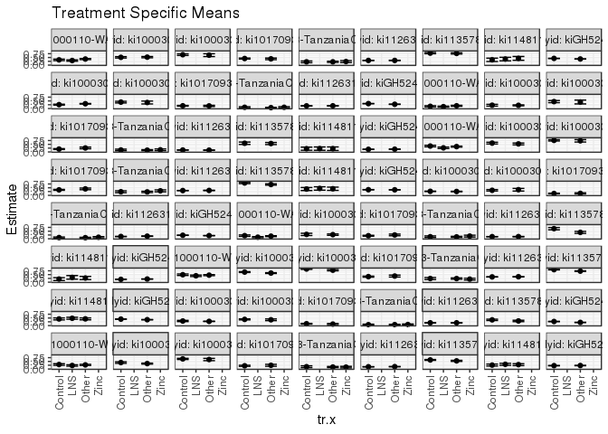

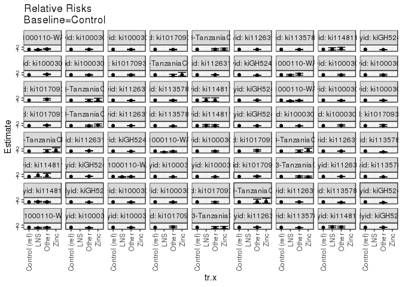

[figure not shown]

[figure not shown]

## Results Table

### Parameter: TSM

| parity | agecat | studyid | country | intervention_level | baseline_level | estimate | ci_lower | ci_upper |
| --- | --- | --- | --- | --- | --- | --- | --- | --- |
| 1 | 0-24 months | ki1000110-WASH-Bangladesh | BANGLADESH | Control | NA | 0.3457447 | 0.2976558 | 0.3938336 |
| 1 | 0-24 months | ki1000110-WASH-Bangladesh | BANGLADESH | LNS | NA | 0.3018868 | 0.2581759 | 0.3455977 |
| 1 | 0-24 months | ki1000110-WASH-Bangladesh | BANGLADESH | Other | NA | 0.3997361 | 0.3648534 | 0.4346189 |
| 1 | 0-24 months | ki1000304b-SAS-CompFeed | INDIA | Control | NA | 0.5111111 | 0.4668406 | 0.5553816 |
| 1 | 0-24 months | ki1000304b-SAS-CompFeed | INDIA | Other | NA | 0.5234899 | 0.4815592 | 0.5654207 |
| 1 | 0-24 months | ki1000304b-SAS-FoodSuppl | INDIA | Control | NA | 0.6842105 | 0.6322987 | 0.7361224 |
| 1 | 0-24 months | ki1000304b-SAS-FoodSuppl | INDIA | Other | NA | 0.6551724 | 0.5624278 | 0.7479170 |
| 1 | 0-24 months | ki1017093b-PROVIDE | BANGLADESH | Control | NA | 0.4328358 | 0.3999215 | 0.4657502 |
| 1 | 0-24 months | ki1017093b-PROVIDE | BANGLADESH | Other | NA | 0.4114286 | 0.3585965 | 0.4642607 |
| 1 | 0-24 months | ki1066203-TanzaniaChild2 | TANZANIA, UNITED REPUBLIC OF | Control | NA | 0.2146597 | 0.1563936 | 0.2729257 |
| 1 | 0-24 months | ki1066203-TanzaniaChild2 | TANZANIA, UNITED REPUBLIC OF | Other | NA | 0.2151589 | 0.1753081 | 0.2550097 |
| 1 | 0-24 months | ki1066203-TanzaniaChild2 | TANZANIA, UNITED REPUBLIC OF | Zinc | NA | 0.2329545 | 0.1704635 | 0.2954456 |
| 1 | 0-24 months | ki1126311-ZVITAMBO | ZIMBABWE | Control | NA | 0.3069388 | 0.3005373 | 0.3133403 |
| 1 | 0-24 months | ki1126311-ZVITAMBO | ZIMBABWE | Other | NA | 0.3066165 | 0.2954673 | 0.3177656 |
| 1 | 0-24 months | ki1135781-COHORTS | GUATEMALA | Control | NA | 0.7900000 | 0.7471950 | 0.8328050 |
| 1 | 0-24 months | ki1135781-COHORTS | GUATEMALA | Other | NA | 0.7701149 | 0.7288707 | 0.8113592 |
| 1 | 0-24 months | ki1148112-iLiNS-DYAD-M | MALAWI | Control | NA | 0.3472222 | 0.2369791 | 0.4574653 |
| 1 | 0-24 months | ki1148112-iLiNS-DYAD-M | MALAWI | LNS | NA | 0.3970588 | 0.2804741 | 0.5136435 |
| 1 | 0-24 months | ki1148112-iLiNS-DYAD-M | MALAWI | Other | NA | 0.4426230 | 0.3176668 | 0.5675791 |
| 1 | 0-24 months | kiGH5241-JiVitA-3 | BANGLADESH | Control | NA | 0.4406897 | 0.4316277 | 0.4497516 |
| 1 | 0-24 months | kiGH5241-JiVitA-3 | BANGLADESH | Other | NA | 0.4025765 | 0.3943113 | 0.4108417 |
| 1 | 0-6 months | ki1000304b-SAS-CompFeed | INDIA | Control | NA | 0.2545455 | 0.2246274 | 0.2844635 |
| 1 | 0-6 months | ki1000304b-SAS-CompFeed | INDIA | Other | NA | 0.3140496 | 0.2953036 | 0.3327956 |
| 1 | 0-6 months | ki1000304b-SAS-FoodSuppl | INDIA | Control | NA | 0.4210526 | 0.3659134 | 0.4761918 |
| 1 | 0-6 months | ki1000304b-SAS-FoodSuppl | INDIA | Other | NA | 0.3965517 | 0.3011009 | 0.4920026 |
| 1 | 0-6 months | ki1017093b-PROVIDE | BANGLADESH | Control | NA | 0.1791045 | 0.1535264 | 0.2046826 |
| 1 | 0-6 months | ki1017093b-PROVIDE | BANGLADESH | Other | NA | 0.1724138 | 0.1318068 | 0.2130208 |
| 1 | 0-6 months | ki1066203-TanzaniaChild2 | TANZANIA, UNITED REPUBLIC OF | Control | NA | 0.0793651 | 0.0408032 | 0.1179270 |
| 1 | 0-6 months | ki1066203-TanzaniaChild2 | TANZANIA, UNITED REPUBLIC OF | Other | NA | 0.0543210 | 0.0322328 | 0.0764091 |
| 1 | 0-6 months | ki1066203-TanzaniaChild2 | TANZANIA, UNITED REPUBLIC OF | Zinc | NA | 0.0804598 | 0.0400179 | 0.1209016 |

[output cut: 135 more lines]

### Parameter: E(Y)

| parity | agecat | studyid | country | intervention_level | baseline_level | estimate | ci_lower | ci_upper |
| --- | --- | --- | --- | --- | --- | --- | --- | --- |
| 1 | 0-24 months | ki1000110-WASH-Bangladesh | BANGLADESH | NA | NA | 0.3600770 | 0.3362338 | 0.3839203 |
| 1 | 0-24 months | ki1000304b-SAS-CompFeed | INDIA | NA | NA | 0.5176056 | 0.4565460 | 0.5786653 |
| 1 | 0-24 months | ki1000304b-SAS-FoodSuppl | INDIA | NA | NA | 0.6623377 | 0.5560159 | 0.7686595 |
| 1 | 0-24 months | ki1017093b-PROVIDE | BANGLADESH | NA | NA | 0.4173554 | 0.3550975 | 0.4796133 |
| 1 | 0-24 months | ki1066203-TanzaniaChild2 | TANZANIA, UNITED REPUBLIC OF | NA | NA | 0.2190722 | 0.1899518 | 0.2481925 |
| 1 | 0-24 months | ki1126311-ZVITAMBO | ZIMBABWE | NA | NA | 0.3066963 | 0.2938401 | 0.3195525 |
| 1 | 0-24 months | ki1135781-COHORTS | GUATEMALA | NA | NA | 0.7807487 | 0.7212896 | 0.8402078 |
| 1 | 0-24 months | ki1148112-iLiNS-DYAD-M | MALAWI | NA | NA | 0.3930348 | 0.3253439 | 0.4607258 |
| 1 | 0-24 months | kiGH5241-JiVitA-3 | BANGLADESH | NA | NA | 0.4216396 | 0.4093039 | 0.4339754 |
| 1 | 0-6 months | ki1000304b-SAS-CompFeed | INDIA | NA | NA | 0.2857143 | 0.2414443 | 0.3299843 |
| 1 | 0-6 months | ki1000304b-SAS-FoodSuppl | INDIA | NA | NA | 0.4025974 | 0.2923393 | 0.5128555 |
| 1 | 0-6 months | ki1017093b-PROVIDE | BANGLADESH | NA | NA | 0.1742739 | 0.1262810 | 0.2222667 |
| 1 | 0-6 months | ki1066203-TanzaniaChild2 | TANZANIA, UNITED REPUBLIC OF | NA | NA | 0.0664063 | 0.0487851 | 0.0840274 |
| 1 | 0-6 months | ki1126311-ZVITAMBO | ZIMBABWE | NA | NA | 0.1768210 | 0.1645146 | 0.1891274 |
| 1 | 0-6 months | kiGH5241-JiVitA-3 | BANGLADESH | NA | NA | 0.3005464 | 0.2882407 | 0.3128522 |
| 1 | 6-24 months | ki1000110-WASH-Bangladesh | BANGLADESH | NA | NA | 0.1542904 | 0.1339455 | 0.1746354 |
| 1 | 6-24 months | ki1000304b-SAS-CompFeed | INDIA | NA | NA | 0.2135417 | 0.1461480 | 0.2809353 |
| 1 | 6-24 months | ki1000304b-SAS-FoodSuppl | INDIA | NA | NA | 0.4347826 | 0.2899436 | 0.5796217 |
| 1 | 6-24 months | ki1017093b-PROVIDE | BANGLADESH | NA | NA | 0.2417582 | 0.1793843 | 0.3041322 |
| 1 | 6-24 months | ki1066203-TanzaniaChild2 | TANZANIA, UNITED REPUBLIC OF | NA | NA | 0.1244168 | 0.0988857 | 0.1499479 |
| 1 | 6-24 months | ki1126311-ZVITAMBO | ZIMBABWE | NA | NA | 0.1196099 | 0.1094189 | 0.1298008 |
| 1 | 6-24 months | ki1135781-COHORTS | GUATEMALA | NA | NA | 0.5632184 | 0.4583923 | 0.6680445 |
| 1 | 6-24 months | ki1148112-iLiNS-DYAD-M | MALAWI | NA | NA | 0.2147239 | 0.1514912 | 0.2779567 |
| 1 | 6-24 months | kiGH5241-JiVitA-3 | BANGLADESH | NA | NA | 0.1757908 | 0.1639734 | 0.1876082 |
| 2 | 0-24 months | ki1000110-WASH-Bangladesh | BANGLADESH | NA | NA | 0.3416321 | 0.3171793 | 0.3660848 |
| 2 | 0-24 months | ki1000304b-SAS-CompFeed | INDIA | NA | NA | 0.5508475 | 0.4650015 | 0.6366934 |
| 2 | 0-24 months | ki1000304b-SAS-FoodSuppl | INDIA | NA | NA | 0.7391304 | 0.6489111 | 0.8293498 |
| 2 | 0-24 months | ki1017093b-PROVIDE | BANGLADESH | NA | NA | 0.4096916 | 0.3455763 | 0.4738070 |
| 2 | 0-24 months | ki1066203-TanzaniaChild2 | TANZANIA, UNITED REPUBLIC OF | NA | NA | 0.2489851 | 0.2177868 | 0.2801834 |
| 2 | 0-24 months | ki1126311-ZVITAMBO | ZIMBABWE | NA | NA | 0.3214086 | 0.3061040 | 0.3367132 |
| 2 | 0-24 months | ki1135781-COHORTS | GUATEMALA | NA | NA | 0.7714286 | 0.7090361 | 0.8338211 |
| 2 | 0-24 months | ki1148112-iLiNS-DYAD-M | MALAWI | NA | NA | 0.4330709 | 0.3718652 | 0.4942765 |
| 2 | 0-24 months | kiGH5241-JiVitA-3 | BANGLADESH | NA | NA | 0.3689637 | 0.3565657 | 0.3813618 |
| 2 | 0-6 months | ki1000304b-SAS-CompFeed | INDIA | NA | NA | 0.2590674 | 0.2388727 | 0.2792620 |
| 2 | 0-6 months | ki1000304b-SAS-FoodSuppl | INDIA | NA | NA | 0.3626374 | 0.2633129 | 0.4619619 |
| 2 | 0-6 months | ki1017093b-PROVIDE | BANGLADESH | NA | NA | 0.1277533 | 0.0842322 | 0.1712744 |
| 2 | 0-6 months | ki1066203-TanzaniaChild2 | TANZANIA, UNITED REPUBLIC OF | NA | NA | 0.0806011 | 0.0608672 | 0.1003349 |
| 2 | 0-6 months | ki1126311-ZVITAMBO | ZIMBABWE | NA | NA | 0.1657122 | 0.1519228 | 0.1795017 |
| 2 | 0-6 months | kiGH5241-JiVitA-3 | BANGLADESH | NA | NA | 0.2191569 | 0.2080052 | 0.2303085 |
| 2 | 6-24 months | ki1000110-WASH-Bangladesh | BANGLADESH | NA | NA | 0.1636520 | 0.1423621 | 0.1849419 |
| 2 | 6-24 months | ki1000304b-SAS-CompFeed | INDIA | NA | NA | 0.2781065 | 0.1910643 | 0.3651488 |
| 2 | 6-24 months | ki1017093b-PROVIDE | BANGLADESH | NA | NA | 0.2391304 | 0.1773295 | 0.3009314 |
| 2 | 6-24 months | ki1066203-TanzaniaChild2 | TANZANIA, UNITED REPUBLIC OF | NA | NA | 0.1392617 | 0.1114428 | 0.1670807 |
| 2 | 6-24 months | ki1126311-ZVITAMBO | ZIMBABWE | NA | NA | 0.1411931 | 0.1283681 | 0.1540180 |
| 2 | 6-24 months | ki1135781-COHORTS | GUATEMALA | NA | NA | 0.5652174 | 0.4633650 | 0.6670698 |
| 2 | 6-24 months | ki1148112-iLiNS-DYAD-M | MALAWI | NA | NA | 0.2623762 | 0.2013093 | 0.3234431 |
| 2 | 6-24 months | kiGH5241-JiVitA-3 | BANGLADESH | NA | NA | 0.1965355 | 0.1835149 | 0.2095561 |
| 3+ | 0-24 months | ki1000110-WASH-Bangladesh | BANGLADESH | NA | NA | 0.4596825 | 0.4350619 | 0.4843032 |
| 3+ | 0-24 months | ki1000304b-SAS-CompFeed | INDIA | NA | NA | 0.6317016 | 0.5861266 | 0.6772767 |
| 3+ | 0-24 months | ki1000304b-SAS-FoodSuppl | INDIA | NA | NA | 0.8114035 | 0.7605149 | 0.8622921 |
| 3+ | 0-24 months | ki1017093b-PROVIDE | BANGLADESH | NA | NA | 0.3953488 | 0.3220676 | 0.4686301 |
| 3+ | 0-24 months | ki1066203-TanzaniaChild2 | TANZANIA, UNITED REPUBLIC OF | NA | NA | 0.2284908 | 0.1975639 | 0.2594177 |
| 3+ | 0-24 months | ki1126311-ZVITAMBO | ZIMBABWE | NA | NA | 0.3568604 | 0.3404803 | 0.3732404 |
| 3+ | 0-24 months | ki1135781-COHORTS | GUATEMALA | NA | NA | 0.7741203 | 0.7464923 | 0.8017483 |
| 3+ | 0-24 months | ki1148112-iLiNS-DYAD-M | MALAWI | NA | NA | 0.4554598 | 0.4184347 | 0.4924848 |
| 3+ | 0-24 months | kiGH5241-JiVitA-3 | BANGLADESH | NA | NA | 0.4076841 | 0.3930086 | 0.4223596 |
| 3+ | 0-6 months | ki1000304b-SAS-CompFeed | INDIA | NA | NA | 0.2907609 | 0.2479343 | 0.3335874 |
| 3+ | 0-6 months | ki1000304b-SAS-FoodSuppl | INDIA | NA | NA | 0.3903509 | 0.3268905 | 0.4538113 |
| 3+ | 0-6 months | ki1017093b-PROVIDE | BANGLADESH | NA | NA | 0.1046512 | 0.0587717 | 0.1505306 |
| 3+ | 0-6 months | ki1066203-TanzaniaChild2 | TANZANIA, UNITED REPUBLIC OF | NA | NA | 0.0639205 | 0.0458384 | 0.0820025 |
| 3+ | 0-6 months | ki1126311-ZVITAMBO | ZIMBABWE | NA | NA | 0.1832441 | 0.1684107 | 0.1980774 |
| 3+ | 0-6 months | ki1135781-COHORTS | GUATEMALA | NA | NA | 0.3379630 | 0.2747357 | 0.4011903 |
| 3+ | 0-6 months | kiGH5241-JiVitA-3 | BANGLADESH | NA | NA | 0.2398637 | 0.2258572 | 0.2538702 |
| 3+ | 6-24 months | ki1000110-WASH-Bangladesh | BANGLADESH | NA | NA | 0.2672269 | 0.2420743 | 0.2923794 |
| 3+ | 6-24 months | ki1000304b-SAS-CompFeed | INDIA | NA | NA | 0.3916084 | 0.3247984 | 0.4584184 |
| 3+ | 6-24 months | ki1000304b-SAS-FoodSuppl | INDIA | NA | NA | 0.6341463 | 0.5486758 | 0.7196169 |
| 3+ | 6-24 months | ki1017093b-PROVIDE | BANGLADESH | NA | NA | 0.2366412 | 0.1635802 | 0.3097023 |
| 3+ | 6-24 months | ki1066203-TanzaniaChild2 | TANZANIA, UNITED REPUBLIC OF | NA | NA | 0.1337907 | 0.1061334 | 0.1614481 |
| 3+ | 6-24 months | ki1126311-ZVITAMBO | ZIMBABWE | NA | NA | 0.1546193 | 0.1406847 | 0.1685538 |
| 3+ | 6-24 months | ki1135781-COHORTS | GUATEMALA | NA | NA | 0.5617978 | 0.5156465 | 0.6079490 |
| 3+ | 6-24 months | ki1148112-iLiNS-DYAD-M | MALAWI | NA | NA | 0.2869875 | 0.2495218 | 0.3244532 |
| 3+ | 6-24 months | kiGH5241-JiVitA-3 | BANGLADESH | NA | NA | 0.2260163 | 0.2106142 | 0.2414184 |

### Parameter: RR

| parity | agecat | studyid | country | intervention_level | baseline_level | estimate | ci_lower | ci_upper |
| --- | --- | --- | --- | --- | --- | --- | --- | --- |
| 1 | 0-24 months | ki1000110-WASH-Bangladesh | BANGLADESH | Control | Control | 1.0000000 | 1.0000000 | 1.0000000 |
| 1 | 0-24 months | ki1000110-WASH-Bangladesh | BANGLADESH | LNS | Control | 0.8731495 | 0.7143211 | 1.0672931 |
| 1 | 0-24 months | ki1000110-WASH-Bangladesh | BANGLADESH | Other | Control | 1.1561599 | 0.9810886 | 1.3624721 |
| 1 | 0-24 months | ki1000304b-SAS-CompFeed | INDIA | Control | Control | 1.0000000 | 1.0000000 | 1.0000000 |
| 1 | 0-24 months | ki1000304b-SAS-CompFeed | INDIA | Other | Control | 1.0242194 | 0.9099955 | 1.1527810 |
| 1 | 0-24 months | ki1000304b-SAS-FoodSuppl | INDIA | Control | Control | 1.0000000 | 1.0000000 | 1.0000000 |
| 1 | 0-24 months | ki1000304b-SAS-FoodSuppl | INDIA | Other | Control | 0.9575597 | 0.8154824 | 1.1243903 |
| 1 | 0-24 months | ki1017093b-PROVIDE | BANGLADESH | Control | Control | 1.0000000 | 1.0000000 | 1.0000000 |
| 1 | 0-24 months | ki1017093b-PROVIDE | BANGLADESH | Other | Control | 0.9505419 | 0.8187624 | 1.1035312 |
| 1 | 0-24 months | ki1066203-TanzaniaChild2 | TANZANIA, UNITED REPUBLIC OF | Control | Control | 1.0000000 | 1.0000000 | 1.0000000 |
| 1 | 0-24 months | ki1066203-TanzaniaChild2 | TANZANIA, UNITED REPUBLIC OF | Other | Control | 1.0023257 | 0.7216014 | 1.3922602 |
| 1 | 0-24 months | ki1066203-TanzaniaChild2 | TANZANIA, UNITED REPUBLIC OF | Zinc | Control | 1.0852273 | 0.7409406 | 1.5894908 |
| 1 | 0-24 months | ki1126311-ZVITAMBO | ZIMBABWE | Control | Control | 1.0000000 | 1.0000000 | 1.0000000 |
| 1 | 0-24 months | ki1126311-ZVITAMBO | ZIMBABWE | Other | Control | 0.9989499 | 0.9579411 | 1.0417143 |
| 1 | 0-24 months | ki1135781-COHORTS | GUATEMALA | Control | Control | 1.0000000 | 1.0000000 | 1.0000000 |
| 1 | 0-24 months | ki1135781-COHORTS | GUATEMALA | Other | Control | 0.9748290 | 0.9033206 | 1.0519982 |
| 1 | 0-24 months | ki1148112-iLiNS-DYAD-M | MALAWI | Control | Control | 1.0000000 | 1.0000000 | 1.0000000 |
| 1 | 0-24 months | ki1148112-iLiNS-DYAD-M | MALAWI | LNS | Control | 1.1435294 | 0.7420505 | 1.7622244 |
| 1 | 0-24 months | ki1148112-iLiNS-DYAD-M | MALAWI | Other | Control | 1.2747541 | 0.8335141 | 1.9495748 |
| 1 | 0-24 months | kiGH5241-JiVitA-3 | BANGLADESH | Control | Control | 1.0000000 | 1.0000000 | 1.0000000 |
| 1 | 0-24 months | kiGH5241-JiVitA-3 | BANGLADESH | Other | Control | 0.9135147 | 0.8873411 | 0.9404604 |
| 1 | 0-6 months | ki1000304b-SAS-CompFeed | INDIA | Control | Control | 1.0000000 | 1.0000000 | 1.0000000 |
| 1 | 0-6 months | ki1000304b-SAS-CompFeed | INDIA | Other | Control | 1.2337662 | 1.0819598 | 1.4068722 |
| 1 | 0-6 months | ki1000304b-SAS-FoodSuppl | INDIA | Control | Control | 1.0000000 | 1.0000000 | 1.0000000 |
| 1 | 0-6 months | ki1000304b-SAS-FoodSuppl | INDIA | Other | Control | 0.9418103 | 0.7160744 | 1.2387076 |
| 1 | 0-6 months | ki1017093b-PROVIDE | BANGLADESH | Control | Control | 1.0000000 | 1.0000000 | 1.0000000 |
| 1 | 0-6 months | ki1017093b-PROVIDE | BANGLADESH | Other | Control | 0.9626437 | 0.7308785 | 1.2679027 |
| 1 | 0-6 months | ki1066203-TanzaniaChild2 | TANZANIA, UNITED REPUBLIC OF | Control | Control | 1.0000000 | 1.0000000 | 1.0000000 |
| 1 | 0-6 months | ki1066203-TanzaniaChild2 | TANZANIA, UNITED REPUBLIC OF | Other | Control | 0.6844444 | 0.3632274 | 1.2897269 |
| 1 | 0-6 months | ki1066203-TanzaniaChild2 | TANZANIA, UNITED REPUBLIC OF | Zinc | Control | 1.0137931 | 0.5038952 | 2.0396632 |

[output cut: 135 more lines]

### Parameter: PAR

| parity | agecat | studyid | country | intervention_level | baseline_level | estimate | ci_lower | ci_upper |
| --- | --- | --- | --- | --- | --- | --- | --- | --- |
| 1 | 0-24 months | ki1000110-WASH-Bangladesh | BANGLADESH | Control | NA | 0.0143323 | -0.0276778 | 0.0563424 |
| 1 | 0-24 months | ki1000304b-SAS-CompFeed | INDIA | Control | NA | 0.0064945 | -0.0360427 | 0.0490317 |
| 1 | 0-24 months | ki1000304b-SAS-FoodSuppl | INDIA | Control | NA | -0.0218729 | -0.1146602 | 0.0709145 |
| 1 | 0-24 months | ki1017093b-PROVIDE | BANGLADESH | Control | NA | -0.0154804 | -0.0683264 | 0.0373655 |
| 1 | 0-24 months | ki1066203-TanzaniaChild2 | TANZANIA, UNITED REPUBLIC OF | Control | NA | 0.0044125 | -0.0462995 | 0.0551245 |
| 1 | 0-24 months | ki1126311-ZVITAMBO | ZIMBABWE | Control | NA | -0.0002424 | -0.0113916 | 0.0109067 |
| 1 | 0-24 months | ki1135781-COHORTS | GUATEMALA | Control | NA | -0.0092513 | -0.0505202 | 0.0320176 |
| 1 | 0-24 months | ki1148112-iLiNS-DYAD-M | MALAWI | Control | NA | 0.0458126 | -0.0437898 | 0.1354150 |
| 1 | 0-24 months | kiGH5241-JiVitA-3 | BANGLADESH | Control | NA | -0.0190500 | -0.0274895 | -0.0106105 |
| 1 | 0-6 months | ki1000304b-SAS-CompFeed | INDIA | Control | NA | 0.0311688 | 0.0009273 | 0.0614104 |
| 1 | 0-6 months | ki1000304b-SAS-FoodSuppl | INDIA | Control | NA | -0.0184552 | -0.1139356 | 0.0770252 |
| 1 | 0-6 months | ki1017093b-PROVIDE | BANGLADESH | Control | NA | -0.0048306 | -0.0454394 | 0.0357782 |
| 1 | 0-6 months | ki1066203-TanzaniaChild2 | TANZANIA, UNITED REPUBLIC OF | Control | NA | -0.0129588 | -0.0456029 | 0.0196852 |
| 1 | 0-6 months | ki1126311-ZVITAMBO | ZIMBABWE | Control | NA | 0.0025291 | -0.0081586 | 0.0132167 |
| 1 | 0-6 months | kiGH5241-JiVitA-3 | BANGLADESH | Control | NA | -0.0217699 | -0.0302911 | -0.0132486 |
| 1 | 6-24 months | ki1000110-WASH-Bangladesh | BANGLADESH | Control | NA | 0.0095093 | -0.0255792 | 0.0445978 |
| 1 | 6-24 months | ki1000304b-SAS-CompFeed | INDIA | Control | NA | -0.0038496 | -0.0352912 | 0.0275920 |
| 1 | 6-24 months | ki1000304b-SAS-FoodSuppl | INDIA | Control | NA | -0.0197628 | -0.1459260 | 0.1064003 |
| 1 | 6-24 months | ki1017093b-PROVIDE | BANGLADESH | Control | NA | 0.0542582 | -0.0008578 | 0.1093743 |
| 1 | 6-24 months | ki1066203-TanzaniaChild2 | TANZANIA, UNITED REPUBLIC OF | Control | NA | -0.0044176 | -0.0486657 | 0.0398306 |
| 1 | 6-24 months | ki1126311-ZVITAMBO | ZIMBABWE | Control | NA | -0.0065440 | -0.0152988 | 0.0022108 |
| 1 | 6-24 months | ki1135781-COHORTS | GUATEMALA | Control | NA | -0.0082102 | -0.0776896 | 0.0612693 |
| 1 | 6-24 months | ki1148112-iLiNS-DYAD-M | MALAWI | Control | NA | 0.0016092 | -0.0800679 | 0.0832862 |
| 1 | 6-24 months | kiGH5241-JiVitA-3 | BANGLADESH | Control | NA | 0.0038136 | -0.0048931 | 0.0125203 |
| 2 | 0-24 months | ki1000110-WASH-Bangladesh | BANGLADESH | Control | NA | -0.0461795 | -0.0893506 | -0.0030085 |
| 2 | 0-24 months | ki1000304b-SAS-CompFeed | INDIA | Control | NA | -0.0307852 | -0.0934818 | 0.0319114 |
| 2 | 0-24 months | ki1000304b-SAS-FoodSuppl | INDIA | Control | NA | -0.0227743 | -0.1027215 | 0.0571728 |
| 2 | 0-24 months | ki1017093b-PROVIDE | BANGLADESH | Control | NA | 0.0476227 | -0.0081236 | 0.1033690 |
| 2 | 0-24 months | ki1066203-TanzaniaChild2 | TANZANIA, UNITED REPUBLIC OF | Control | NA | 0.0106431 | -0.0413340 | 0.0626203 |
| 2 | 0-24 months | ki1126311-ZVITAMBO | ZIMBABWE | Control | NA | 0.0057378 | -0.0075557 | 0.0190313 |
| 2 | 0-24 months | ki1135781-COHORTS | GUATEMALA | Control | NA | -0.0448980 | -0.0900543 | 0.0002584 |
| 2 | 0-24 months | ki1148112-iLiNS-DYAD-M | MALAWI | Control | NA | 0.0164042 | -0.0620080 | 0.0948164 |
| 2 | 0-24 months | kiGH5241-JiVitA-3 | BANGLADESH | Control | NA | -0.0035027 | -0.0121172 | 0.0051118 |
| 2 | 0-6 months | ki1000304b-SAS-CompFeed | INDIA | Control | NA | -0.0067554 | -0.0214864 | 0.0079756 |
| 2 | 0-6 months | ki1000304b-SAS-FoodSuppl | INDIA | Control | NA | 0.0293040 | -0.0583116 | 0.1169196 |
| 2 | 0-6 months | ki1017093b-PROVIDE | BANGLADESH | Control | NA | 0.0070636 | -0.0307938 | 0.0449211 |
| 2 | 0-6 months | ki1066203-TanzaniaChild2 | TANZANIA, UNITED REPUBLIC OF | Control | NA | 0.0020671 | -0.0308919 | 0.0350260 |
| 2 | 0-6 months | ki1126311-ZVITAMBO | ZIMBABWE | Control | NA | 0.0161521 | 0.0040093 | 0.0282949 |
| 2 | 0-6 months | kiGH5241-JiVitA-3 | BANGLADESH | Control | NA | -0.0114923 | -0.0191588 | -0.0038259 |
| 2 | 6-24 months | ki1000110-WASH-Bangladesh | BANGLADESH | Control | NA | -0.0412950 | -0.0811417 | -0.0014482 |
| 2 | 6-24 months | ki1000304b-SAS-CompFeed | INDIA | Control | NA | -0.0097723 | -0.0553550 | 0.0358105 |
| 2 | 6-24 months | ki1017093b-PROVIDE | BANGLADESH | Control | NA | 0.0391304 | -0.0156231 | 0.0938839 |
| 2 | 6-24 months | ki1066203-TanzaniaChild2 | TANZANIA, UNITED REPUBLIC OF | Control | NA | 0.0055038 | -0.0405131 | 0.0515206 |
| 2 | 6-24 months | ki1126311-ZVITAMBO | ZIMBABWE | Control | NA | 0.0016247 | -0.0095340 | 0.0127835 |
| 2 | 6-24 months | ki1135781-COHORTS | GUATEMALA | Control | NA | -0.1014493 | -0.1712186 | -0.0316800 |
| 2 | 6-24 months | ki1148112-iLiNS-DYAD-M | MALAWI | Control | NA | 0.0568968 | -0.0215037 | 0.1352972 |
| 2 | 6-24 months | kiGH5241-JiVitA-3 | BANGLADESH | Control | NA | 0.0114961 | 0.0021286 | 0.0208636 |
| 3+ | 0-24 months | ki1000110-WASH-Bangladesh | BANGLADESH | Control | NA | -0.0320302 | -0.0771979 | 0.0131376 |
| 3+ | 0-24 months | ki1000304b-SAS-CompFeed | INDIA | Control | NA | -0.0333469 | -0.0712124 | 0.0045186 |
| 3+ | 0-24 months | ki1000304b-SAS-FoodSuppl | INDIA | Control | NA | -0.0574490 | -0.1029873 | -0.0119106 |
| 3+ | 0-24 months | ki1017093b-PROVIDE | BANGLADESH | Control | NA | 0.0294952 | -0.0347525 | 0.0937429 |
| 3+ | 0-24 months | ki1066203-TanzaniaChild2 | TANZANIA, UNITED REPUBLIC OF | Control | NA | -0.0126856 | -0.0684693 | 0.0430980 |
| 3+ | 0-24 months | ki1126311-ZVITAMBO | ZIMBABWE | Control | NA | 0.0083755 | -0.0057321 | 0.0224831 |
| 3+ | 0-24 months | ki1135781-COHORTS | GUATEMALA | Control | NA | -0.0527090 | -0.0744444 | -0.0309735 |
| 3+ | 0-24 months | ki1148112-iLiNS-DYAD-M | MALAWI | Control | NA | 0.0165457 | -0.0376327 | 0.0707242 |
| 3+ | 0-24 months | kiGH5241-JiVitA-3 | BANGLADESH | Control | NA | -0.0188280 | -0.0292246 | -0.0084313 |
| 3+ | 0-6 months | ki1000304b-SAS-CompFeed | INDIA | Control | NA | -0.0126099 | -0.0257849 | 0.0005651 |
| 3+ | 0-6 months | ki1000304b-SAS-FoodSuppl | INDIA | Control | NA | -0.0194852 | -0.0736344 | 0.0346640 |
| 3+ | 0-6 months | ki1017093b-PROVIDE | BANGLADESH | Control | NA | -0.0173001 | -0.0564347 | 0.0218346 |
| 3+ | 0-6 months | ki1066203-TanzaniaChild2 | TANZANIA, UNITED REPUBLIC OF | Control | NA | 0.0047489 | -0.0266481 | 0.0361458 |
| 3+ | 0-6 months | ki1126311-ZVITAMBO | ZIMBABWE | Control | NA | -0.0004294 | -0.0131644 | 0.0123056 |
| 3+ | 0-6 months | ki1135781-COHORTS | GUATEMALA | Control | NA | -0.0409844 | -0.0873339 | 0.0053651 |
| 3+ | 0-6 months | kiGH5241-JiVitA-3 | BANGLADESH | Control | NA | -0.0309315 | -0.0402839 | -0.0215791 |
| 3+ | 6-24 months | ki1000110-WASH-Bangladesh | BANGLADESH | Control | NA | -0.0279761 | -0.0753045 | 0.0193524 |
| 3+ | 6-24 months | ki1000304b-SAS-CompFeed | INDIA | Control | NA | -0.0359278 | -0.0798755 | 0.0080199 |
| 3+ | 6-24 months | ki1000304b-SAS-FoodSuppl | INDIA | Control | NA | -0.0325203 | -0.1084759 | 0.0434353 |
| 3+ | 6-24 months | ki1017093b-PROVIDE | BANGLADESH | Control | NA | 0.0245200 | -0.0394633 | 0.0885033 |
| 3+ | 6-24 months | ki1066203-TanzaniaChild2 | TANZANIA, UNITED REPUBLIC OF | Control | NA | -0.0172884 | -0.0684981 | 0.0339213 |
| 3+ | 6-24 months | ki1126311-ZVITAMBO | ZIMBABWE | Control | NA | 0.0065254 | -0.0055064 | 0.0185572 |
| 3+ | 6-24 months | ki1135781-COHORTS | GUATEMALA | Control | NA | -0.0370723 | -0.0731728 | -0.0009718 |
| 3+ | 6-24 months | ki1148112-iLiNS-DYAD-M | MALAWI | Control | NA | 0.0271005 | -0.0271835 | 0.0813846 |
| 3+ | 6-24 months | kiGH5241-JiVitA-3 | BANGLADESH | Control | NA | 0.0039206 | -0.0068730 | 0.0147142 |

### Parameter: PAF

| parity | agecat | studyid | country | intervention_level | baseline_level | estimate | ci_lower | ci_upper |
| --- | --- | --- | --- | --- | --- | --- | --- | --- |
| 1 | 0-24 months | ki1000110-WASH-Bangladesh | BANGLADESH | Control | NA | 0.0398035 | -0.0842530 | 0.1496659 |
| 1 | 0-24 months | ki1000304b-SAS-CompFeed | INDIA | Control | NA | 0.0125472 | -0.0720505 | 0.0904692 |
| 1 | 0-24 months | ki1000304b-SAS-FoodSuppl | INDIA | Control | NA | -0.0330237 | -0.1883945 | 0.1020338 |
| 1 | 0-24 months | ki1017093b-PROVIDE | BANGLADESH | Control | NA | -0.0370918 | -0.1771223 | 0.0862807 |
| 1 | 0-24 months | ki1066203-TanzaniaChild2 | TANZANIA, UNITED REPUBLIC OF | Control | NA | 0.0201417 | -0.2409652 | 0.2263100 |
| 1 | 0-24 months | ki1126311-ZVITAMBO | ZIMBABWE | Control | NA | -0.0007905 | -0.0378409 | 0.0349372 |
| 1 | 0-24 months | ki1135781-COHORTS | GUATEMALA | Control | NA | -0.0118493 | -0.0667767 | 0.0402499 |
| 1 | 0-24 months | ki1148112-iLiNS-DYAD-M | MALAWI | Control | NA | 0.1165612 | -0.1436968 | 0.3175952 |
| 1 | 0-24 months | kiGH5241-JiVitA-3 | BANGLADESH | Control | NA | -0.0451808 | -0.0663272 | -0.0244537 |
| 1 | 0-6 months | ki1000304b-SAS-CompFeed | INDIA | Control | NA | 0.1090909 | 0.0099061 | 0.1983397 |
| 1 | 0-6 months | ki1000304b-SAS-FoodSuppl | INDIA | Control | NA | -0.0458404 | -0.3258553 | 0.1750365 |
| 1 | 0-6 months | ki1017093b-PROVIDE | BANGLADESH | Control | NA | -0.0277186 | -0.2974387 | 0.1859304 |
| 1 | 0-6 months | ki1066203-TanzaniaChild2 | TANZANIA, UNITED REPUBLIC OF | Control | NA | -0.1951447 | -0.7998145 | 0.2063788 |
| 1 | 0-6 months | ki1126311-ZVITAMBO | ZIMBABWE | Control | NA | 0.0143030 | -0.0471153 | 0.0721188 |
| 1 | 0-6 months | kiGH5241-JiVitA-3 | BANGLADESH | Control | NA | -0.0724343 | -0.1033302 | -0.0424035 |
| 1 | 6-24 months | ki1000110-WASH-Bangladesh | BANGLADESH | Control | NA | 0.0616324 | -0.1955902 | 0.2635154 |
| 1 | 6-24 months | ki1000304b-SAS-CompFeed | INDIA | Control | NA | -0.0180276 | -0.1796071 | 0.1214192 |
| 1 | 6-24 months | ki1000304b-SAS-FoodSuppl | INDIA | Control | NA | -0.0454545 | -0.3975409 | 0.2179297 |
| 1 | 6-24 months | ki1017093b-PROVIDE | BANGLADESH | Control | NA | 0.2244318 | 0.0232411 | 0.3841817 |
| 1 | 6-24 months | ki1066203-TanzaniaChild2 | TANZANIA, UNITED REPUBLIC OF | Control | NA | -0.0355061 | -0.4597856 | 0.2654586 |
| 1 | 6-24 months | ki1126311-ZVITAMBO | ZIMBABWE | Control | NA | -0.0547111 | -0.1348457 | 0.0197650 |
| 1 | 6-24 months | ki1135781-COHORTS | GUATEMALA | Control | NA | -0.0145773 | -0.1478030 | 0.1031850 |
| 1 | 6-24 months | ki1148112-iLiNS-DYAD-M | MALAWI | Control | NA | 0.0074941 | -0.4560518 | 0.3234665 |
| 1 | 6-24 months | kiGH5241-JiVitA-3 | BANGLADESH | Control | NA | 0.0216941 | -0.0279907 | 0.0689776 |
| 2 | 0-24 months | ki1000110-WASH-Bangladesh | BANGLADESH | Control | NA | -0.1351733 | -0.2689161 | -0.0155270 |
| 2 | 0-24 months | ki1000304b-SAS-CompFeed | INDIA | Control | NA | -0.0558870 | -0.1834427 | 0.0579203 |
| 2 | 0-24 months | ki1000304b-SAS-FoodSuppl | INDIA | Control | NA | -0.0308123 | -0.1485774 | 0.0748782 |
| 2 | 0-24 months | ki1017093b-PROVIDE | BANGLADESH | Control | NA | 0.1162403 | -0.0129616 | 0.2289626 |
| 2 | 0-24 months | ki1066203-TanzaniaChild2 | TANZANIA, UNITED REPUBLIC OF | Control | NA | 0.0427461 | -0.1904904 | 0.2302878 |
| 2 | 0-24 months | ki1126311-ZVITAMBO | ZIMBABWE | Control | NA | 0.0178521 | -0.0236238 | 0.0576474 |
| 2 | 0-24 months | ki1135781-COHORTS | GUATEMALA | Control | NA | -0.0582011 | -0.1220830 | 0.0020440 |
| 2 | 0-24 months | ki1148112-iLiNS-DYAD-M | MALAWI | Control | NA | 0.0378788 | -0.1614000 | 0.2029643 |
| 2 | 0-24 months | kiGH5241-JiVitA-3 | BANGLADESH | Control | NA | -0.0094934 | -0.0333414 | 0.0138042 |
| 2 | 0-6 months | ki1000304b-SAS-CompFeed | INDIA | Control | NA | -0.0260759 | -0.0861562 | 0.0306810 |
| 2 | 0-6 months | ki1000304b-SAS-FoodSuppl | INDIA | Control | NA | 0.0808081 | -0.1707123 | 0.2782908 |
| 2 | 0-6 months | ki1017093b-PROVIDE | BANGLADESH | Control | NA | 0.0552913 | -0.2707626 | 0.2976859 |
| 2 | 0-6 months | ki1066203-TanzaniaChild2 | TANZANIA, UNITED REPUBLIC OF | Control | NA | 0.0256456 | -0.4823909 | 0.3595707 |
| 2 | 0-6 months | ki1126311-ZVITAMBO | ZIMBABWE | Control | NA | 0.0974709 | 0.0287332 | 0.1613439 |
| 2 | 0-6 months | kiGH5241-JiVitA-3 | BANGLADESH | Control | NA | -0.0524389 | -0.0899515 | -0.0162173 |
| 2 | 6-24 months | ki1000110-WASH-Bangladesh | BANGLADESH | Control | NA | -0.2523340 | -0.5197269 | -0.0319884 |
| 2 | 6-24 months | ki1000304b-SAS-CompFeed | INDIA | Control | NA | -0.0351386 | -0.2198618 | 0.1216120 |
| 2 | 6-24 months | ki1017093b-PROVIDE | BANGLADESH | Control | NA | 0.1636364 | -0.0528229 | 0.3355918 |
| 2 | 6-24 months | ki1066203-TanzaniaChild2 | TANZANIA, UNITED REPUBLIC OF | Control | NA | 0.0395211 | -0.3547808 | 0.3190635 |
| 2 | 6-24 months | ki1126311-ZVITAMBO | ZIMBABWE | Control | NA | 0.0115072 | -0.0697871 | 0.0866239 |
| 2 | 6-24 months | ki1135781-COHORTS | GUATEMALA | Control | NA | -0.1794872 | -0.3365932 | -0.0408477 |
| 2 | 6-24 months | ki1148112-iLiNS-DYAD-M | MALAWI | Control | NA | 0.2168519 | -0.1442769 | 0.4640100 |
| 2 | 6-24 months | kiGH5241-JiVitA-3 | BANGLADESH | Control | NA | 0.0584939 | 0.0124460 | 0.1023947 |
| 3+ | 0-24 months | ki1000110-WASH-Bangladesh | BANGLADESH | Control | NA | -0.0696789 | -0.1726554 | 0.0242548 |
| 3+ | 0-24 months | ki1000304b-SAS-CompFeed | INDIA | Control | NA | -0.0527890 | -0.1177448 | 0.0083919 |
| 3+ | 0-24 months | ki1000304b-SAS-FoodSuppl | INDIA | Control | NA | -0.0708019 | -0.1326515 | -0.0123298 |
| 3+ | 0-24 months | ki1017093b-PROVIDE | BANGLADESH | Control | NA | 0.0746055 | -0.0888614 | 0.2135316 |
| 3+ | 0-24 months | ki1066203-TanzaniaChild2 | TANZANIA, UNITED REPUBLIC OF | Control | NA | -0.0555192 | -0.3301474 | 0.1624080 |
| 3+ | 0-24 months | ki1126311-ZVITAMBO | ZIMBABWE | Control | NA | 0.0234700 | -0.0159120 | 0.0613253 |
| 3+ | 0-24 months | ki1135781-COHORTS | GUATEMALA | Control | NA | -0.0680888 | -0.0985417 | -0.0384801 |
| 3+ | 0-24 months | ki1148112-iLiNS-DYAD-M | MALAWI | Control | NA | 0.0363276 | -0.0903044 | 0.1482520 |
| 3+ | 0-24 months | kiGH5241-JiVitA-3 | BANGLADESH | Control | NA | -0.0461827 | -0.0732293 | -0.0198178 |
| 3+ | 0-6 months | ki1000304b-SAS-CompFeed | INDIA | Control | NA | -0.0433687 | -0.0918521 | 0.0029618 |
| 3+ | 0-6 months | ki1000304b-SAS-FoodSuppl | INDIA | Control | NA | -0.0499171 | -0.2062170 | 0.0861297 |
| 3+ | 0-6 months | ki1017093b-PROVIDE | BANGLADESH | Control | NA | -0.1653116 | -0.6961280 | 0.1993816 |
| 3+ | 0-6 months | ki1066203-TanzaniaChild2 | TANZANIA, UNITED REPUBLIC OF | Control | NA | 0.0742932 | -0.5730020 | 0.4552245 |
| 3+ | 0-6 months | ki1126311-ZVITAMBO | ZIMBABWE | Control | NA | -0.0023433 | -0.0744815 | 0.0649517 |
| 3+ | 0-6 months | ki1135781-COHORTS | GUATEMALA | Control | NA | -0.1212689 | -0.2869736 | 0.0231004 |
| 3+ | 0-6 months | kiGH5241-JiVitA-3 | BANGLADESH | Control | NA | -0.1289546 | -0.1742059 | -0.0854471 |
| 3+ | 6-24 months | ki1000110-WASH-Bangladesh | BANGLADESH | Control | NA | -0.1046903 | -0.2967250 | 0.0589056 |
| 3+ | 6-24 months | ki1000304b-SAS-CompFeed | INDIA | Control | NA | -0.0917443 | -0.2218870 | 0.0245369 |
| 3+ | 6-24 months | ki1000304b-SAS-FoodSuppl | INDIA | Control | NA | -0.0512821 | -0.1850968 | 0.0674231 |
| 3+ | 6-24 months | ki1017093b-PROVIDE | BANGLADESH | Control | NA | 0.1036168 | -0.1753221 | 0.3163552 |
| 3+ | 6-24 months | ki1066203-TanzaniaChild2 | TANZANIA, UNITED REPUBLIC OF | Control | NA | -0.1292197 | -0.5839924 | 0.1949853 |
| 3+ | 6-24 months | ki1126311-ZVITAMBO | ZIMBABWE | Control | NA | 0.0422030 | -0.0353318 | 0.1139314 |
| 3+ | 6-24 months | ki1135781-COHORTS | GUATEMALA | Control | NA | -0.0659887 | -0.1368255 | 0.0004342 |
| 3+ | 6-24 months | ki1148112-iLiNS-DYAD-M | MALAWI | Control | NA | 0.0944310 | -0.1157910 | 0.2650458 |
| 3+ | 6-24 months | kiGH5241-JiVitA-3 | BANGLADESH | Control | NA | 0.0173465 | -0.0307274 | 0.0631782 |